# Informe para Alcoholistas V2

Alejandro Blasco

2023-08-05

## Introducción

### Descripción

*¿Qué datos son?*

La base posee datos sobre diferentes vinos y sus reseñas. El detalle de los datos se transcribe del diccionario:

```r
diccionario <- data.frame(
  Variable = c("pais", "nombre", "puntos", "precio", "provincia", "zona_1", "zona_2", "variedad", "vina", "titulo_resena"),
  Clase = c("caracter", "caracter", "entero", "entero", "caracter", "caracter", "caracter", "caracter", "caracter", "caracter"),
  Descripción = c("País de origen", "Nombre del vino", "Puntos con que fue calificado (1 a 100)", "Precio de la botella (en dólares)",
                  "Lugar de origen", "Información adicional sobre zona de origen", "Más información adicional",
                  "Variedad (ie, Pinot Noir)", "Nombre de la viña", "Título de la reseña")
)
dicc_url = "https://github.com/cienciadedatos/datos-de-miercoles/tree/master/datos/2019/2019-06-12"
dicc_pie = "Fuente: '<a href=\"dicc_url\">Datos de Miércoles</a>', proyecto semanal de datos organizado por la comunidad de R."

diccionario |>
  gt(rowname_col = "Variable") |>
  tab_options(table.width = "75%") |>
  opt_stylize(style = 5, color = 'cyan') |>
  # tab_stubhead(label = "Variable") |>
  # gt_theme_dark() |>
  tab_source_note(html(dicc_pie))
```

|  | Clase | Descripción |
| --- | --- | --- |
| pais | caracter | País de origen |
| nombre | caracter | Nombre del vino |
| puntos | entero | Puntos con que fue calificado (1 a 100) |
| precio | entero | Precio de la botella (en dólares) |
| provincia | caracter | Lugar de origen |
| zona_1 | caracter | Información adicional sobre zona de origen |
| zona_2 | caracter | Más información adicional |
| variedad | caracter | Variedad (ie, Pinot Noir) |
| vina | caracter | Nombre de la viña |
| titulo_resena | caracter | Título de la reseña |

Fuente: 'Datos de Miércoles', proyecto semanal de datos organizado por la comunidad de R.

### Origen

*¿De dónde provienen?*

La fuente de los datos es la revista [Wine Enthusiast](http://www.winemag.com/?s=&drink_type=wine), extraidos por *zackthoutt* y alojados en [Kaggle](https://www.kaggle.com/zynicide/wine-reviews), de donde fueron tomados y luego traducidos.

*¿Quién los tomó?*

[figure not shown]

### Fecha

*¿En qué período se tomaron?*

El dataset en español es de 2019-06-12 (dato obtenido de la [url](https://raw.githubusercontent.com/cienciadedatos/datos-de-miercoles/master/datos/2019/2019-06-12/vinos.csv) de origen del dataset).

El original en inglés de Keggle fue actualizado por última vez hace 5 años (2018), pero no se indica la fecha exacta de procedencia de los datos.

## Análisis

*Exploración de los datos*

### Muestreo

Primero se cargan los datos:

```r
vinos  <-  read_csv('datos/vinos.csv', show_col_types = FALSE)
```

Luego se presenta una muestra:

```r
sample_n(vinos, 5) |>
  gt() |>
  # tab_options(table.background.color = "#25303f",
  #             heading.background.color = "#003258") |>
  gt_theme_pff() |>
  # gt_highlight_cols(columns = c(puntos,precio), fill = "#e4e8ec")  |>
  tab_header(title = "Reseñas de Vinos") |>
   tab_footnote(
    footnote = "Muestra aleatoria de 5 registros.",
    locations = cells_title("title")) |>
  tab_source_note(
    source_note = html("Fuente: Revista <a href=\"www.wineenthusiast.com\">Wine Enthusiast</a>."))
```

Reseñas de Vinos<sup>1</sup>

| pais | nombre | puntos | precio | provincia | region_1 | region_2 | variedad | vina | titulo_resena |
| --- | --- | --- | --- | --- | --- | --- | --- | --- | --- |
| Estados Unidos | East Side Vineyards | 82 | 14 | California | Dry Creek Valley | Sonoma | Sauvignon Blanc | Pedroncelli | Pedroncelli 2012 East Side Vineyards Sauvignon Blanc (Dry Creek Valley) |
| Nueva Zelanda | NA | 85 | 25 | Marlborough | NA | NA | Pinot Gris | Spy Valley | Spy Valley 2006 Pinot Gris (Marlborough) |
| Estados Unidos | Old Vines | 94 | 99 | Washington | Washington | Washington Other | Cabernet Sauvignon | Woodward Canyon | Woodward Canyon 2013 Old Vines Cabernet Sauvignon (Washington) |
| Estados Unidos | Heritage Vines Alegria Vineyards | 91 | 28 | California | Russian River Valley | Sonoma | Zinfandel | Acorn | Acorn 2000 Heritage Vines Alegria Vineyards Zinfandel (Russian River Valley) |
| Italia | Vigna del Cuc | 88 | 16 | Veneto | Valdobbiadene Prosecco Superiore | NA | Sparkling Blend | Case Bianche | Case Bianche 2014 Vigna del Cuc (Valdobbiadene Prosecco Superiore) |

Fuente: Revista Wine Enthusiast.  
<sup>1</sup> Muestra aleatoria de 5 registros.

Se almacenan las dimensiones de la base en variables:

```r
observaciones <- nrow(vinos)
variables <- ncol(vinos)
```

El dataset tiene `129971` observaciones y `10` variables.

### Variables a analizar

Se consideran las variables `puntos` y `precio` para el análisis, ya que son las únicas numéricas, por lo que permiten mayores análisis que el resto de las variables del dataset, que son categóricas.

### Tendencia Central

¿Cuál es su valor medio y desvío estándar?

Medidas de Tendencia Central

|  | Media | Mediana | Moda | Desvío |
| --- | --- | --- | --- | --- |
| Puntos | 88.45 | 88 | 88 | 3.04 |
| Precio | 35.36 | 25 | 20 | 41.02 |

*Puntos*

Por la media y el desvío, se puede estimar, asumiendo que las calificaciones tienen distribución normal, que el 68% de la muestra se encuentra entre `85` y `91` puntos.

La similitud entre media, mediana y moda permite suponer una distribución, si no normal, al menos simétrica.

*Precio*

Por la media y el desvío, se puede suponer que la distribución no es normal.

La diferencia entre moda, mediana y media, confirma esto, permitiendo estimar una distribución asimétrica hacia la derecha.

### Rango

¿Cuál es su rango (valor máximo y valor mínimo)?

```r
pts_rng <- summarise(vinos,
                     min = min(puntos, na.rm = TRUE),
                     max = max(puntos, na.rm = TRUE))

pre_rng <- summarise(vinos,
                     min = min(precio, na.rm = TRUE),
                     max = max(precio, na.rm = TRUE))

rng <- rbind(pts_rng, pre_rng) |>
  add_column("variable" = c("Puntos","Precio"),
             .before = "min") |>
  gt(rowname_col = 'variable') |>
  tab_header(
    title = "Rango") |>
  cols_label(min = "Mínimo",
             max = "Máximo") |>
  opt_stylize(style = 2, color = 'cyan')
rng
```

Rango

|  | Mínimo | Máximo |
| --- | --- | --- |
| Puntos | 80 | 100 |
| Precio | 4 | 3300 |

*Puntos*

Puede observarse que los puntos no bajan de `80`, por lo que la calificación oscila en un rango de solo `20` puntos.

*Precio*

Se confirma que los precios altos tienen gran dispersión y se alejan mucho de la media, lo que ratifica una asimetría hacia la derecha.

### Anomalías

¿Hay alguna anomalía que sugiera que hay datos incorrectos?

No hay evidencias de que existan anomalías en los datos, solo algunos valores llamativos, como la diferencia entre la media de precios y los precios máximos, ya que, aunque el máximo es US$`3300`, solo existen `1177` (de un total de `129971`) que superen los US$`158` (promedio de precio + 3 desvíos estándar).

También llamó la atención la cantidad de cepas o variedades de vino (`707`), pero únicamente porque superó ampliamente el número esperado.

La dispersión de precios puede observarse mejor mediante un gráfico. Primero seteamos un tema:

```r
theme_set(theme_dark() +
            theme(plot.background = element_rect(fill = "#555555"),
                  axis.text = element_text(color = "#222222"),
                  legend.background = element_rect(fill = "#888888")
                  ))
```

Y luego graficamos:

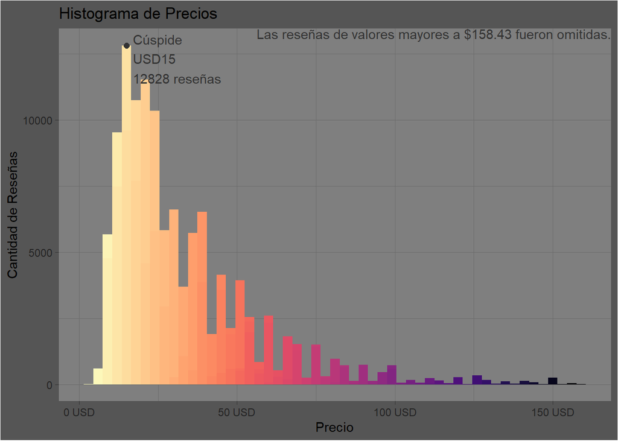

```r
p <- vinos |>
  filter(precio <= precio_caro) |>
  ggplot() +
  geom_histogram(binwidth = 3,
                 show.legend = FALSE,
                 aes(x = precio,fill = cut(precio, 100))) +
  scale_fill_viridis_d(option = "A", direction = -1) +
  scale_x_continuous(labels = scales::dollar_format(suffix = " USD", prefix = "")) +
  labs(title = "Histograma de Precios",
       # caption = paste0("Las reseñas de valores mayores a ",
       #                   paste0("$", round(precio_caro,2)), " fueron omitidas."),
       x = "Precio",
       y = "Cantidad de Reseñas")

#ver https://community.rstudio.com/t/geom-histogram-max-bin-height/10026
#ver https://github.com/tidyverse/ggplot2/issues/5004
cuspide <- select(layer_data(p)[which.max(layer_data(p)$y), ],x,y)

# Añade la marca y la nota al pie
p <- p +
  geom_text(data = cuspide,
            aes(x = x, y = y,
                label = paste0("Cúspide\nUSD", x, "\n", y," reseñas")),
            nudge_x = 2, nudge_y = -500, color = "#333333", hjust = 0) +
  geom_point(data = cuspide,
             aes(x = x, y = y),
             shape = 20, size = 3, fill = NA, color = "#333333") +
  annotate("text", x = Inf, y = Inf, hjust = 1, vjust = 1,
           label = paste0("Las reseñas de valores mayores a ",
                         paste0("$", round(precio_caro,2)), " fueron omitidas."),
           color = "#333333")  # Nota en la parte superior del área del gráfico

show(p)
```

(los precios mayores a `158` fueron excluidos)

### Tamaño

¿Cuántas observaciones hay por cada grupo? ¿Cuántos valores faltantes? ¿Hay diferencias?

Se contabiliza el porcentaje de valores N/A (vacíos), para cada una de las variables:

```r
proporcion <- tibble::rownames_to_column(data.frame(colSums(is.na(vinos))/nrow(vinos)),
                                                  "variable")
colnames(proporcion)[2] <- "Cantidad de NA"
proporcion |>
gt() |>
  gt_theme_pff() |>
  fmt_percent(columns = 2, decimals = 2)
```

| variable | Cantidad de NA |
| --- | --- |
| pais | 0.05% |
| nombre | 28.83% |
| puntos | 0.00% |
| precio | 6.92% |
| provincia | 0.05% |
| region_1 | 16.35% |
| region_2 | 61.14% |
| variedad | 0.00% |
| vina | 0.00% |
| titulo_resena | 0.00% |

## Hipótesis

Se presentan 3 hipótesis:

1. Podría existir una diferencia notable entre el promedio de precios de los vinos según el país.
2. Habría una incremento en el precio promedio del vino conforme su puntaje.
3. Existirían variedades que podrían tener un precio promedio significativamente mayor, pero no así su puntaje.

### *Precio x Pais*

> Podría existir una diferencia notable entre el promedio de precios de los vinos según el país.

Para analizar esto, primero, se realiza un gráfico para ver los promedios de precio x país:

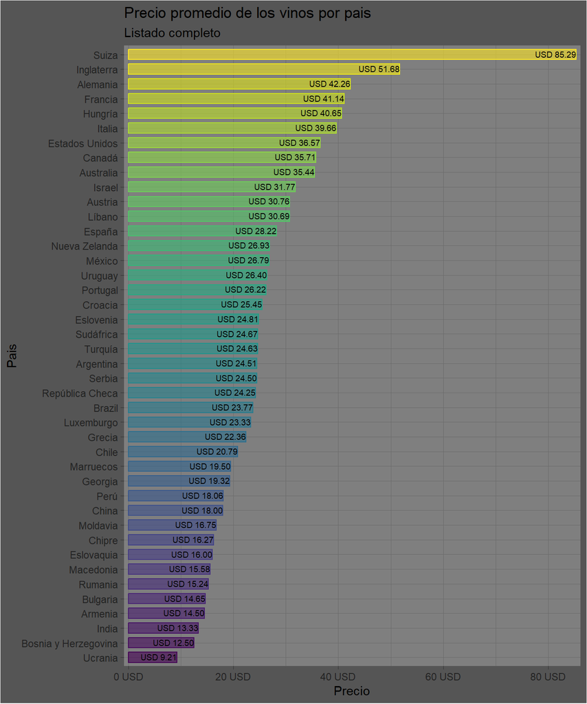

```r
# https://sebastiansauer.github.io/figure_sizing_knitr/

paleta_pais <- createPalette(43,  c("#ff0000", "#00ff00", "#0000ff")) # paleta personalizada. no funca

vinos |>
  filter(!is.na(pais)) |>
  group_by(pais) |>
  summarise(precio_promedio = mean(precio, na.rm = TRUE)) |>
  filter(!is.na(precio_promedio)) |>
  ggplot(aes(precio_promedio, reorder(pais, precio_promedio))) +
  geom_col(width = 0.7, alpha = 0.6, show.legend = FALSE,
           aes(fill = reorder(pais, precio_promedio),
               color=reorder(pais, precio_promedio))) +
  scale_fill_viridis_d(aesthetics = c("colour", "fill")) +
  scale_x_continuous(expand = c(0.01,0),
                     labels = scales::dollar_format(suffix = " USD", prefix = "")) +
  # scale_colour_manual(values = paleta_pais,aesthetics = c("colour", "fill")) + #no logré que funcione
  geom_text(aes(label = sprintf("USD %.2f", precio_promedio)),
            hjust = 1, size = 2.5, nudge_y = 0.04) +
  labs(title = "Precio promedio de los vinos por pais",
       subtitle = "Listado completo",
       x = "Precio", y = "Pais")
```

Se ve una gran dispersión, con precios que van desde menos de US$10 (Ucrania), hasta más de US$85 (Suiza).

Para verificar que estos promedios sean estadísticamente significativos, se analiza cuantas reseñas hay de cada pais:

```r
vinos |>
  filter(!is.na(pais)) |>
  group_by(pais) |>
  summarise(resenias = n()) |>
  arrange(resenias) |>
  head(10) |>
  gt() |>
  tab_header(title = "Paises con menos reseñas") |>
  cols_label(pais = "País", resenias = "Reseñas") |>
  gt_theme_dark()
```

Paises con menos reseñas

| País | Reseñas |
| --- | --- |
| China | 1 |
| Egipto | 1 |
| Eslovaquia | 1 |
| Armenia | 2 |
| Bosnia y Herzegovina | 2 |
| Luxemburgo | 6 |
| Suiza | 7 |
| India | 9 |
| Chipre | 11 |
| Macedonia | 12 |

Destacan varios paises casi sin reseñas. Gráficamente:

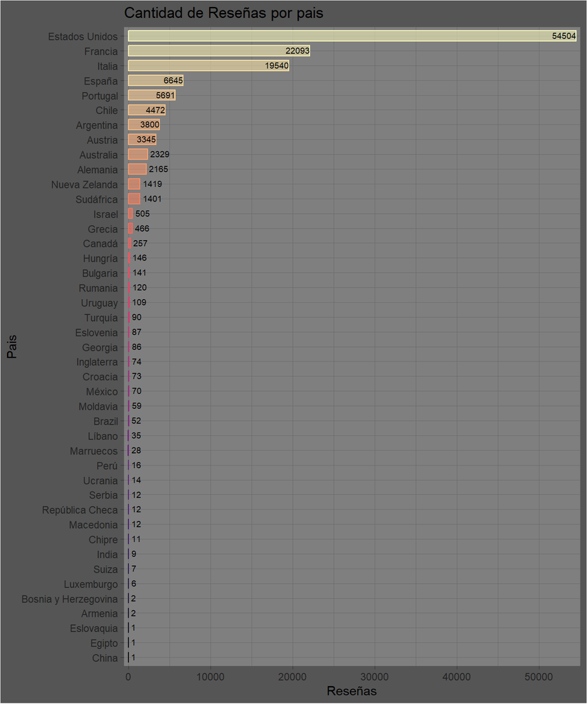

```r
vinos |>
  filter(!is.na(pais)) |>
  group_by(pais) |>
  summarise(resenias = n()) |>
  ggplot(aes(resenias, reorder(pais, resenias))) +
  geom_col(width = 0.7, show.legend = FALSE,
           aes(color=reorder(pais, resenias),
           fill=reorder(pais, resenias),
           alpha = 0.6)) +
  geom_text(data = . %>% filter(resenias > 3000), aes(label = resenias),
            hjust = 1, size = 2.5, nudge_y = 0.04) +
  geom_text(data = . %>% filter(resenias < 3000), aes(label = resenias),
            hjust = 0, size = 2.5, nudge_x = 350, nudge_y = 0.04) +
    scale_fill_viridis_d(option = "A",
                       direction = 1,
                       aesthetics = c("colour", "fill")) +
  scale_x_continuous(expand = c(.01,0)) +
  labs(title = "Cantidad de Reseñas por pais",
       x = "Reseñas",
       y = "Pais")
```

Al existir paises con tan pocas reseñas, conviene filtrarlos o agruparlos:

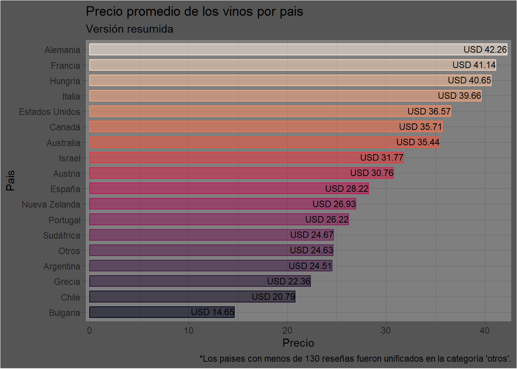

```r
prop_resenias = 0.001
vinos |>
  filter(!is.na(pais)) |>
  group_by(pais = fct_lump_prop(pais, prop_resenias, other_level = "Otros")) |>
  summarise(precio_promedio = mean(precio, na.rm = TRUE), resenias = n()) |>
  filter(!is.na(precio_promedio)) |>
  ggplot(aes(precio_promedio,
             reorder(pais, precio_promedio))) +
  geom_col(width = 0.7, show.legend = FALSE,
           aes(color=reorder(pais, precio_promedio),
               fill=reorder(pais, precio_promedio),
               alpha = 0.6)) +
  geom_text(aes(label = sprintf("USD %.2f", precio_promedio)),
            hjust = 1, size = 3, nudge_y = 0.04) +
  scale_fill_viridis_d(option = "F",
                       direction = 1,
                       aesthetics = c("colour", "fill")) +
  scale_x_continuous(expand = c(0.01,0)) +
    labs(title = "Precio promedio de los vinos por pais",
       subtitle = "Versión resumida",
       caption = paste0("*Los paises con menos de ",
                         round(tamanio_muestra*prop_resenias,0),
                        " reseñas fueron unificados en la categoría 'otros'."),
       x = "Precio", y = "Pais")
```

Otros = paises con pocas reseñas

(<0,1% del tamaño de la muestra)

*Conclusiones:* Se constata una diferencia significativa entre los precios promedio según el pais de origen del vino, ya sea contabilizando todos o excluyendo los menos representativos.

Tampoco es posible determinar los motivos de la variación de precio. Puede suponerse que influya la reputación vitivinícola, el tamaño de las economías (países con economías desarrolladas parecen ocupar los 1ros puestos), u otras causas.

### *Precio vs Puntaje*

> Habría una incremento en el precio promedio del vino conforme su puntaje.

Primeramente, se elabora un gráfico de dispersión de la relación puntaje y precio, eliminando vinos de precios muy altos (> 1000), ya que limitan la utilidad el gráfico:

Este gráfico brinda poca información. Parecería que existen vinos de precio bajo en casi todos los puntajes, y el precio mínimo parece elevarse ligeramente a partir del puntaje 95.

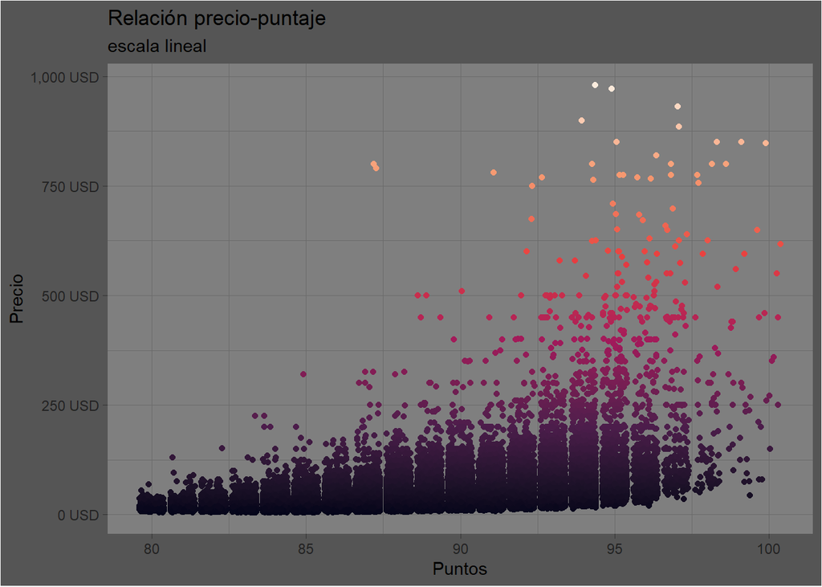

```r
p <- vinos |>
  filter(!is.na(puntos)) |>
  filter(!is.na(precio)) |>
  filter(precio < 1000) |>
  ggplot(aes(x=puntos, y=precio, color=precio)) +
  scale_y_continuous(labels = scales::dollar_format(suffix = " USD", prefix = "")) +
  geom_jitter(show.legend = FALSE) +
  # scale_color_gradientn(colors = brewer.pal(5, "YlOrBr")) +
  scale_color_viridis_c(option = "F", direction = 1) +
  # scale_color_gradient(low="blue", high="red") +
  labs(title = "Relación precio-puntaje",
       subtitle = "escala lineal",
       x = "Puntos", y = "Precio", colour = "Precio")
show(p)
```

Si cambiamos la escala:

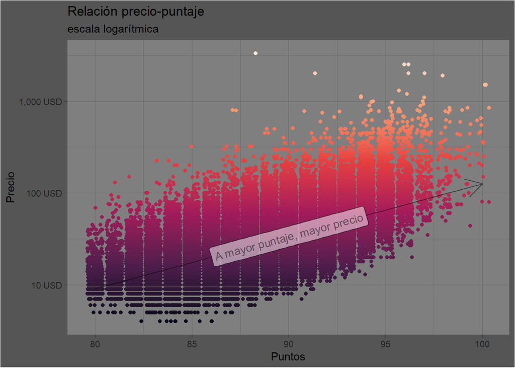

```r
q <- vinos |>
  filter(!is.na(puntos)) |>
  filter(!is.na(precio)) |>
  ggplot(aes(x = puntos, y = precio)) +
  scale_y_log10(labels = scales::dollar_format(suffix = " USD", prefix = "")) +
  geom_jitter(aes(colour = precio), show.legend = FALSE) +  # Mover la estética aquí
  scale_color_viridis_c(option = "F", direction = 1, trans = "log") +
  labs(title = "Relación precio-puntaje",
       subtitle = "escala logarítmica",
       x = "Puntos", y = "Precio") +
  geom_labelsmooth(method = "lm",
                   formula = y ~ x,
                   label = "A mayor puntaje, mayor precio", alpha = 0.5,
                   arrow = arrow())
    # stat_smooth(method = "lm",
    #         formula = y ~ x,
    #         geom = "smooth",
    #         color="black")
show(q)
```

Una escala logarítmica permite apreciar mucho mejor la relación existente entre precio y puntaje.

Vamos a comprobar el precio promedio para cada puntaje:

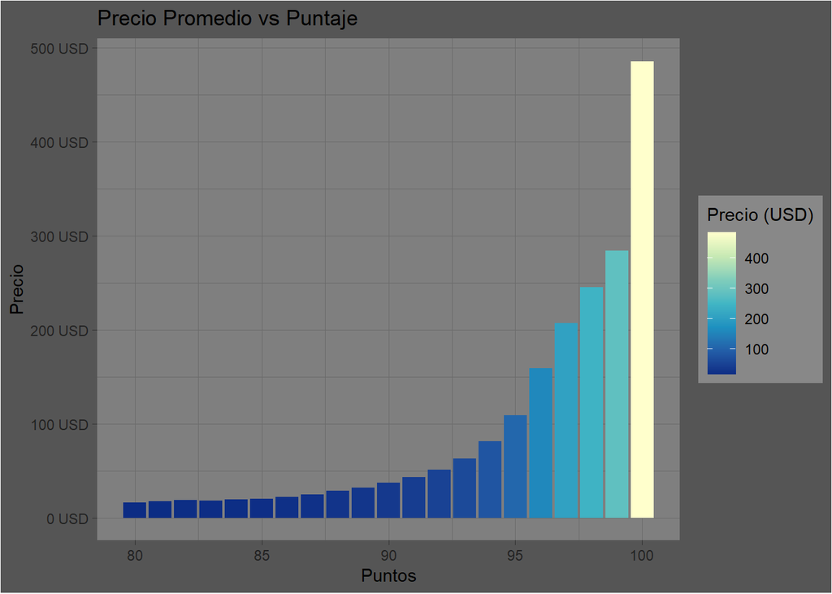

```r
p <- vinos |>
  filter(!is.na(puntos)) |>
  filter(!is.na(precio)) |>
  group_by(puntos) |>
  summarise(precio_promedio = mean(precio, na.rm = TRUE)) |>
  ggplot(aes(x=puntos, y=precio_promedio, fill=precio_promedio)) +
  scale_y_continuous(labels = scales::dollar_format(suffix = " USD", prefix = "")) +
  geom_col() +
  scale_fill_distiller(palette = "YlGnBu") +
  labs(title = "Precio Promedio vs Puntaje",
       x = "Puntos", y = "Precio", fill = "Precio (USD)")
show(p)
```

Con esto se aprecia que el precio promedio de los vino se incrementa, pero el crecimiento sigue una tendencia más exponencial que lineal.

También podemos observar como se distribuyen los puntajes:

```r
vinos |>
  filter(!is.na(puntos)) |>
  filter(!is.na(precio)) |>
  group_by(puntos) |>
  summarise(precio_promedio = mean(precio, na.rm = TRUE), resenias = n()) |>
  gt() |>
  tab_header(title = "Relaciones", subtitle = "Puntos vs Precio Promedio vs Reseñas") |>
  cols_label(puntos = "Puntos", precio_promedio = "Precio Promedio", resenias = "Reseñas") |>
  fmt_number(col = 2, decimals = 2) |>
  gt_theme_dark()
```

Relaciones

Puntos vs Precio Promedio vs Reseñas

| Puntos | Precio Promedio | Reseñas |
| --- | --- | --- |
| 80 | 16.37 | 395 |
| 81 | 17.18 | 680 |
| 82 | 18.87 | 1772 |
| 83 | 18.24 | 2886 |
| 84 | 19.31 | 6099 |
| 85 | 19.95 | 8902 |
| 86 | 22.13 | 11745 |
| 87 | 24.90 | 15767 |
| 88 | 28.69 | 16014 |
| 89 | 32.17 | 11324 |
| 90 | 36.91 | 14361 |
| 91 | 43.22 | 10564 |
| 92 | 51.04 | 8871 |
| 93 | 63.11 | 5935 |
| 94 | 81.44 | 3449 |
| 95 | 109.24 | 1406 |
| 96 | 159.29 | 482 |
| 97 | 207.17 | 207 |
| 98 | 245.49 | 69 |
| 99 | 284.21 | 28 |
| 100 | 485.95 | 19 |

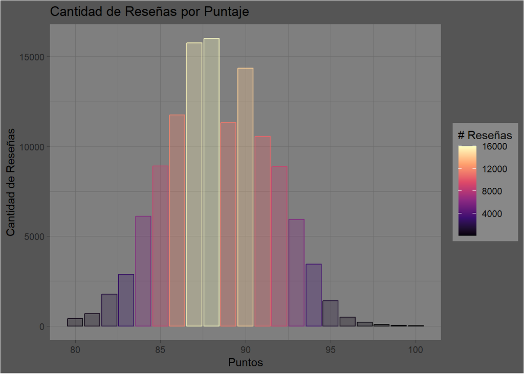

```r
vinos |>
  filter(!is.na(puntos)) |>
  filter(!is.na(precio)) |>
  group_by(puntos) |>
  summarise(precio_promedio = mean(precio, na.rm = TRUE), resenias = n()) |>
  ggplot(aes(x = puntos, y = resenias)) +
  geom_col(aes(colour = resenias, fill = resenias),width = 0.9, alpha = 0.3) +
  scale_fill_viridis_c(option = "A",
                       direction = 1,
                       aesthetics = c("colour", "fill")) +
  # scale_fill_distiller(palette = "YlGnBu") +
  labs(title = "Cantidad de Reseñas por Puntaje",
       color = "# Reseñas",
       fill = "# Reseñas",
       x = "Puntos",
       y = "Cantidad de Reseñas")
```

Se observa que los puntajes parecerían tene una distribución semejante a la normal.

Por último, para relacionar con la hipótesis 1, comparamos puntaje promedio conforme paises:

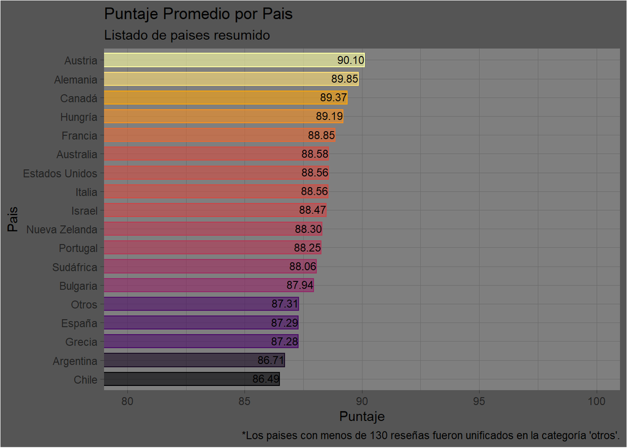

```r
vinos |>
  filter(!is.na(pais)) |>
  group_by(pais = fct_lump_prop(pais, prop_resenias, other_level = "Otros")) |>
  # group_by(pais) |>
  summarise(puntos_promedio = mean(puntos, na.rm = TRUE), resenias = n()) |>
  # filter(resenias > tamanio_muestra/1000) |>
  filter(!is.na(puntos_promedio)) |>
  ggplot(aes(puntos_promedio, reorder(pais, puntos_promedio))) +
  geom_col(width = 0.7,
           aes(color = puntos_promedio,
               fill = puntos_promedio),
           alpha = 0.6,
           show.legend = FALSE) +
  geom_text(aes(label = sprintf("%.2f", puntos_promedio)),
            hjust = 1, size = 3, nudge_y = 0.04) +
  scale_fill_viridis_c(option = "B",
                       direction = 1,
                       aesthetics = c("colour", "fill")) +
  labs(title = "Puntaje Promedio por Pais",
       subtitle = "Listado de paises resumido",
       caption = paste0("*Los paises con menos de ",
                         round(tamanio_muestra*prop_resenias,0),
                        " reseñas fueron unificados en la categoría 'otros'."),
       x = "Puntaje",
       y = "Pais") +
  coord_cartesian(xlim = c(80, 100))
```

Se ve, que al contrario del precio promedio, el puntaje promedio no parecería tiene mucha variabilidad.

*Conclusiones:* Entendemos que existe una correlación entre el puntaje y el precio, aunque desconocemos si esto puede deberse a un sesgo de quien evalúa (que podría tender a asignar puntajes altos a vinos caros) o a una efectiva correlación entre calidad y precio, ya que hay muchos vinos de bajo precio con alto puntaje.

### *Precio/Puntaje x Variedad*

> Existirían variedades que podrían tener un precio promedio significativamente mayor, pero no así su puntaje.

```r
vinos |>
  filter(!is.na(variedad)) |>
  group_by(variedad) |>
  summarise(puntos_promedio = mean(puntos, na.rm = TRUE),
            precio_promedio = mean(precio, na.rm = TRUE),
            resenias = n()) |>
  arrange(resenias) |>
  head(10) |>
  gt(rowname_col = "variedad") |>
  tab_header(title = "Variedades de Vino", subtitle = "Muestra de variedades con escasas Reseñas") |>
  tab_stubhead(label = "Variedad") |>
  cols_label(puntos_promedio = "Puntaje Promedio",
             precio_promedio = "Precio Promedio",
             resenias = "Reseñas") |>
  gt_theme_dark()
```

Variedades de Vino

Muestra de variedades con escasas Reseñas

| Variedad | Puntaje Promedio | Precio Promedio | Reseñas |
| --- | --- | --- | --- |
| Aidani | 82 | 27 | 1 |
| Albanello | 86 | 20 | 1 |
| Athiri | 83 | 18 | 1 |
| Babosa Negro | 92 | 45 | 1 |
| Barbera-Nebbiolo | 87 | 30 | 1 |
| Biancale | 85 | 18 | 1 |
| Biancolella | 85 | 26 | 1 |
| Biancu Gentile | 89 | NaN | 1 |
| Blatina | 88 | 12 | 1 |
| Blauburger | 87 | 17 | 1 |

Por la cantidad de variedades encontradas (`707`), y la escasa cantidad de reseñas de muchas, se agrupan en “Otras” las variedades sin una cantidad significativa de reseñas.

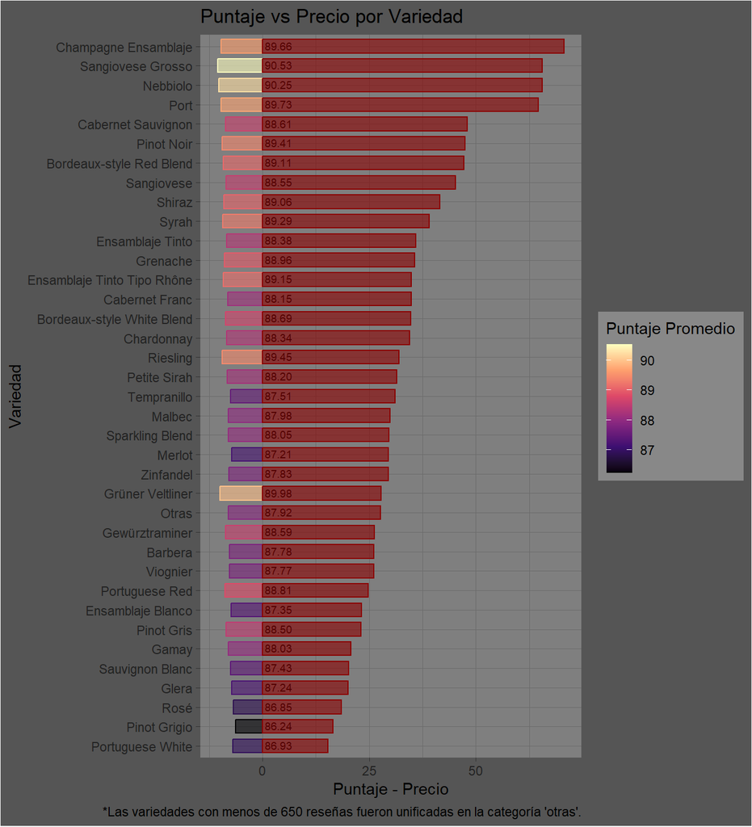

```r
resenia_x_variedad = 0.005
paleta_rdylbu <- brewer.pal(11, "RdYlBu")

vinos |>
  filter(!is.na(variedad)) |>
  group_by(variedad = fct_lump_min(variedad, tamanio_muestra*resenia_x_variedad, other_level = "Otras")) |>
  summarise(puntos_promedio = mean(puntos, na.rm = TRUE),
            precio_promedio = mean(precio, na.rm = TRUE),
            resenias = n()) |>
  ## filter(resenias > tamanio_muestra/200) |>
  arrange(resenias) |>
  ggplot() +
  geom_col(aes(-puntos_promedio+80,
               reorder(variedad, precio_promedio),
           color=puntos_promedio,
           fill=puntos_promedio),
           width = 0.7,
           alpha = 0.6) +
  geom_text(aes(0,
               reorder(variedad, precio_promedio),
                label = sprintf("%.2f", puntos_promedio)),
            hjust = 0, size = 2.5, nudge_x = 0.5,nudge_y = 0.04) +
  scale_color_viridis_c(option = "A", direction = 1, aesthetics = c("colour", "fill")) +
  geom_col(aes(precio_promedio,
               reorder(variedad, precio_promedio)),
               fill="red4",
               color="red4",
           width = 0.7,
           alpha = 0.6) +
  # scale_fill_gradient(low = "#4B0082", high = "#D3B9D3", aesthetics = c("colour", "fill")) +
    labs(title = "Puntaje vs Precio por Variedad",
       caption = paste0("*Las variedades con menos de ",
                         round(tamanio_muestra*resenia_x_variedad,0),
                        " reseñas fueron unificadas en la categoría 'otras'."),
       color = "Puntaje Promedio",
       fill = "Puntaje Promedio",
       x = "Puntaje - Precio",
       y = "Variedad")
```

Para este gráfico, se opusieron puntaje a la izquierda (escala de 80 a 100) y precio a la derecha.

`Links Consultados:`

```r
# https://aberdeenstudygroup.github.io/studyGroup/lessons/SG-T1-GitHubVersionControl/VersionControl/
# https://bbc.github.io/rcookbook/
# https://bookdown.org/yihui/rmarkdown-cookbook/fold-show.html
# https://bookdown.org/yihui/rmarkdown/html-document.html#floating_toc
# https://buddy.works/blog/5-types-of-git-workflows
# https://campus.unab.edu.ar/pluginfile.php/115477/mod_resource/content/1/ggplot2-theme-elements-reference-v2.pdf
# https://cran.r-project.org/web/packages/ymlthis/vignettes/yaml-fieldguide.html
# https://github.com/EmilHvitfeldt/r-color-palettes#palettes-sorted-by-package-alphabetically
# https://github.com/jrnold/ggthemes
# https://gt.albert-rapp.de/getting_started
# https://gt.rstudio.com/articles/intro-creating-gt-tables.html
# https://imagecolorpicker.com/color-code/25303f
# https://inbo.github.io/git-course/course_rstudio.html
# https://isabella-b.com/files/ggplot2-theme-elements-reference-v2.pdf
# https://monashdatafluency.github.io/r-rep-res/yaml-header.html
# https://rdrr.io/github/jthomasmock/gtExtras/src/R/gt_theme_dark.R
# https://www.garrickadenbuie.com/blog/pandoc-syntax-highlighting-examples/
```